# Red wine Quality Exploratory Data Analysis using R by Prem Mithilesh

```
## [1] 1599   13
```

This Chunk implies the Dimensions of the DataSet, The dataset has 1599 rows with 13 columns. Which means the dataset contains 1599 entries of wine and it contains 13 varibles that implies the quality of the wine.

```
##  [1] "X"                    "fixed.acidity"        "volatile.acidity"
##  [4] "citric.acid"          "residual.sugar"       "chlorides"
##  [7] "free.sulfur.dioxide"  "total.sulfur.dioxide" "density"
## [10] "pH"                   "sulphates"            "alcohol"
## [13] "quality"
```

Displays the names of each varible in the dataset.

```
##        X          fixed.acidity   volatile.acidity  citric.acid
##  Min.   :   1.0   Min.   : 4.60   Min.   :0.1200   Min.   :0.000
##  1st Qu.: 400.5   1st Qu.: 7.10   1st Qu.:0.3900   1st Qu.:0.090
##  Median : 800.0   Median : 7.90   Median :0.5200   Median :0.260
##  Mean   : 800.0   Mean   : 8.32   Mean   :0.5278   Mean   :0.271
##  3rd Qu.:1199.5   3rd Qu.: 9.20   3rd Qu.:0.6400   3rd Qu.:0.420
##  Max.   :1599.0   Max.   :15.90   Max.   :1.5800   Max.   :1.000
##  residual.sugar     chlorides       free.sulfur.dioxide
##  Min.   : 0.900   Min.   :0.01200   Min.   : 1.00
##  1st Qu.: 1.900   1st Qu.:0.07000   1st Qu.: 7.00
##  Median : 2.200   Median :0.07900   Median :14.00
##  Mean   : 2.539   Mean   :0.08747   Mean   :15.87
##  3rd Qu.: 2.600   3rd Qu.:0.09000   3rd Qu.:21.00
##  Max.   :15.500   Max.   :0.61100   Max.   :72.00
##  total.sulfur.dioxide    density             pH          sulphates
##  Min.   :  6.00       Min.   :0.9901   Min.   :2.740   Min.   :0.3300
##  1st Qu.: 22.00       1st Qu.:0.9956   1st Qu.:3.210   1st Qu.:0.5500
##  Median : 38.00       Median :0.9968   Median :3.310   Median :0.6200
##  Mean   : 46.47       Mean   :0.9967   Mean   :3.311   Mean   :0.6581
##  3rd Qu.: 62.00       3rd Qu.:0.9978   3rd Qu.:3.400   3rd Qu.:0.7300
##  Max.   :289.00       Max.   :1.0037   Max.   :4.010   Max.   :2.0000
##     alcohol         quality
##  Min.   : 8.40   Min.   :3.000
##  1st Qu.: 9.50   1st Qu.:5.000
##  Median :10.20   Median :6.000
##  Mean   :10.42   Mean   :5.636
##  3rd Qu.:11.10   3rd Qu.:6.000
##  Max.   :14.90   Max.   :8.000
```

The Summary of the dataset can be understood, It displays the Statistical Dimensions of the Dataset like: Quartile, MEan, Min and Max which helps in understanding each varible and helps in further Exploration.

```
##   X fixed.acidity volatile.acidity citric.acid residual.sugar chlorides
## 1 1           7.4             0.70        0.00            1.9     0.076
## 2 2           7.8             0.88        0.00            2.6     0.098
## 3 3           7.8             0.76        0.04            2.3     0.092
## 4 4          11.2             0.28        0.56            1.9     0.075
## 5 5           7.4             0.70        0.00            1.9     0.076
## 6 6           7.4             0.66        0.00            1.8     0.075
##   free.sulfur.dioxide total.sulfur.dioxide density   pH sulphates alcohol
## 1                  11                   34  0.9978 3.51      0.56     9.4
## 2                  25                   67  0.9968 3.20      0.68     9.8
## 3                  15                   54  0.9970 3.26      0.65     9.8
## 4                  17                   60  0.9980 3.16      0.58     9.8
## 5                  11                   34  0.9978 3.51      0.56     9.4
## 6                  13                   40  0.9978 3.51      0.56     9.4
##   quality
## 1       5
## 2       5
## 3       5
## 4       6
## 5       5
## 6       5
```

Displays the first 6 rows of the dataset which helps better understand the actual arrangement of the data in the dataset.

```
##  [1] "fixed.acidity"        "volatile.acidity"     "citric.acid"
##  [4] "residual.sugar"       "chlorides"            "free.sulfur.dioxide"
##  [7] "total.sulfur.dioxide" "density"              "pH"
## [10] "sulphates"            "alcohol"              "quality"
```

```
## [1] 1599   12
```

We dropped a varible X and new Dimension of the Dataset is displayed. It can be observed that the Varible X is dropped and hence there are only 12 varibles.

# Observation from the Data set:

The wines with a quality rating of 3,4 were rated as bad, 5,6 as average and 7,8 were rated as good.

# Univariate Plots Section

[figure not shown]

As quality plays a major role in the Analysis lets us make an Individual plot for quality for better visulization and understanding.

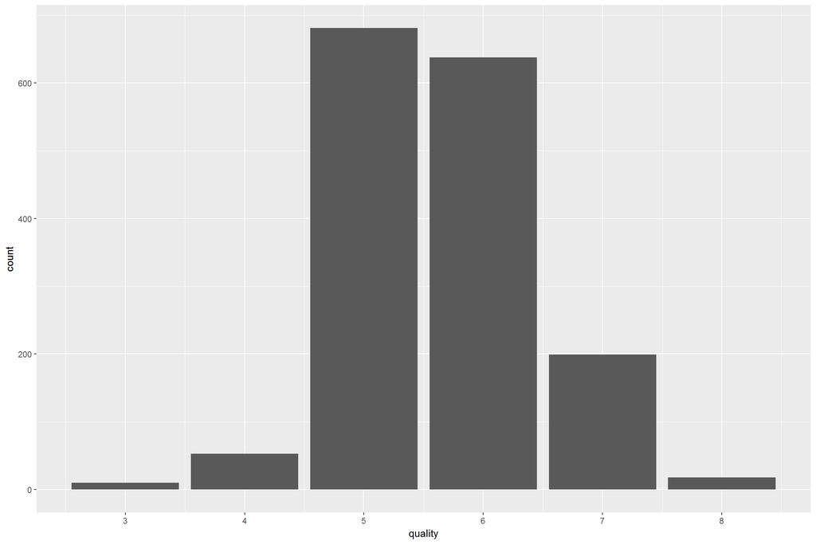

As Quality is Dependent factor that determines the quality of wine, it has been plotted seprately.

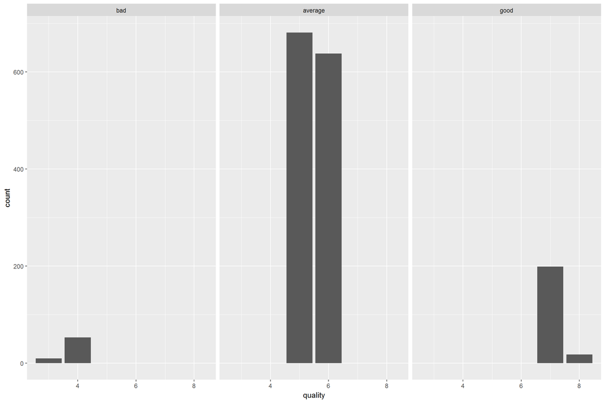

As we can see from the above plot, The Data set has a major wine collection that belongs to the “Average” Category followed by “good” and “bad”.

```
##     bad average    good
##      63    1319     217
```

from the above plot and Summary it can be observed that most of the wines were found to be classified as average quality(1319) followed by good(217) followed by bad(63).

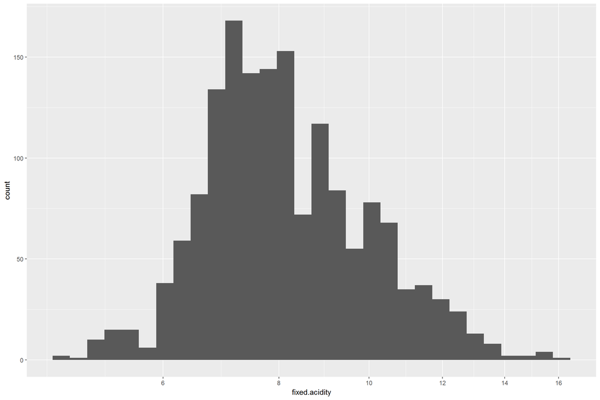

As the fixed.acidity and volatile.acidity have skewed distrubutions when plotted above, Let us plot them Individually and Visualize them by plotting X on Scale Log10 to better understand the Distribution.

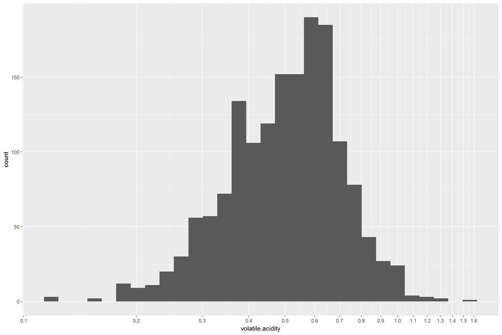

As fixed.acidity and Volatile.acidity had skewed distrubutions, They have been plotted on Scale X of Log10 to see if they were normalized.

# Univariate Analysis

The plots were developed to observe the trend of each charecteristis and various observations can be made from the plot. 1. The residual.sugars in most wine were concentrated around 2 and is long tailed. 2. Density and Ph distrubution is normalized. 3. Major part of the of the Data has Chloride distribution less than 0.2. 4. Residual.sugars and sulphates have skewed distrubutions.

### What is the structure of your dataset?

```
## 'data.frame':    1599 obs. of  13 variables:
##  $ fixed.acidity       : num  7.4 7.8 7.8 11.2 7.4 7.4 7.9 7.3 7.8 7.5 ...
##  $ volatile.acidity    : num  0.7 0.88 0.76 0.28 0.7 0.66 0.6 0.65 0.58 0.5 ...
##  $ citric.acid         : num  0 0 0.04 0.56 0 0 0.06 0 0.02 0.36 ...
##  $ residual.sugar      : num  1.9 2.6 2.3 1.9 1.9 1.8 1.6 1.2 2 6.1 ...
##  $ chlorides           : num  0.076 0.098 0.092 0.075 0.076 0.075 0.069 0.065 0.073 0.071 ...
##  $ free.sulfur.dioxide : num  11 25 15 17 11 13 15 15 9 17 ...
##  $ total.sulfur.dioxide: num  34 67 54 60 34 40 59 21 18 102 ...
##  $ density             : num  0.998 0.997 0.997 0.998 0.998 ...
##  $ pH                  : num  3.51 3.2 3.26 3.16 3.51 3.51 3.3 3.39 3.36 3.35 ...
##  $ sulphates           : num  0.56 0.68 0.65 0.58 0.56 0.56 0.46 0.47 0.57 0.8 ...
##  $ alcohol             : num  9.4 9.8 9.8 9.8 9.4 9.4 9.4 10 9.5 10.5 ...
##  $ quality             : int  5 5 5 6 5 5 5 7 7 5 ...
##  $ rating              : Ord.factor w/ 3 levels "bad"<"average"<..: 2 2 2 2 2 2 2 3 3 2 ...
```

This displays Compactly the internal structure of an R object or the Dataset. The dataset is mostly of type numerical with two Exceptions,Quality Varible of type Int and rating of type Ordered Factor.

### What is/are the main feature(s) of interest in your dataset?

1. The skewed distrubutions were found to be normalized when plotted with Scale x on log10.
2. Most of the wines are classified under the quality of 5 and 6 which is taken as an Average Rating.

### What other features in the dataset do you think will help support your investigation into your feature(s) of interest?

The quality of a wine is not absolute. It depends on who and How’s one judging it. It is usually a combined opinion.

### Did you create any new variables from existing variables in the dataset?

Yes, A new varible(Rating) has been created, It categorizes the quality varible into three types: Good, Average and Bad.

### Of the features you investigated, were there any unusual distributions? Did you perform any operations on the data to tidy, adjust, or change the form of the data? If so, why did you do this?

Citric.Acid, Fixed.Acidity and volatile.acidity Distrubutions were observed to be unusual. Fixed.acidity and Volatile.acidity were were found to be normalized when plotted with Scale x on log10

# Bivariate Plots Section

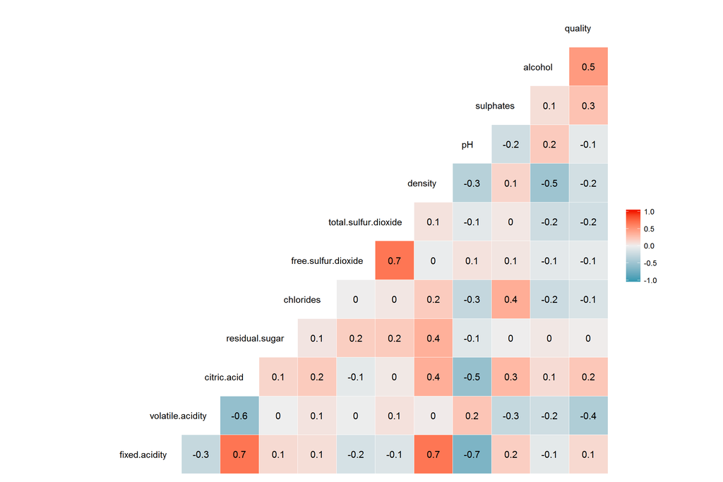

This plot helps us quickly analyse the Co-relations of all varible against each other in one glance.

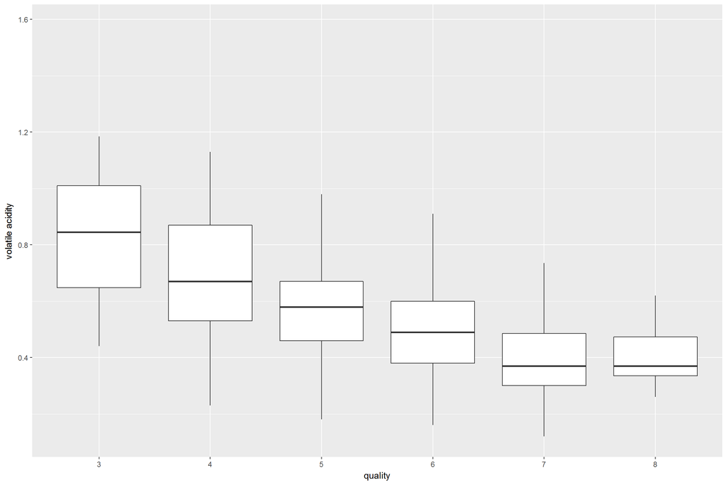

The median of the box plot has been decreasing as the quality goes higher and is found to be stabilized at end as it reaches higher quality. Good quality wines have lower volatile.acidity around 0.4.

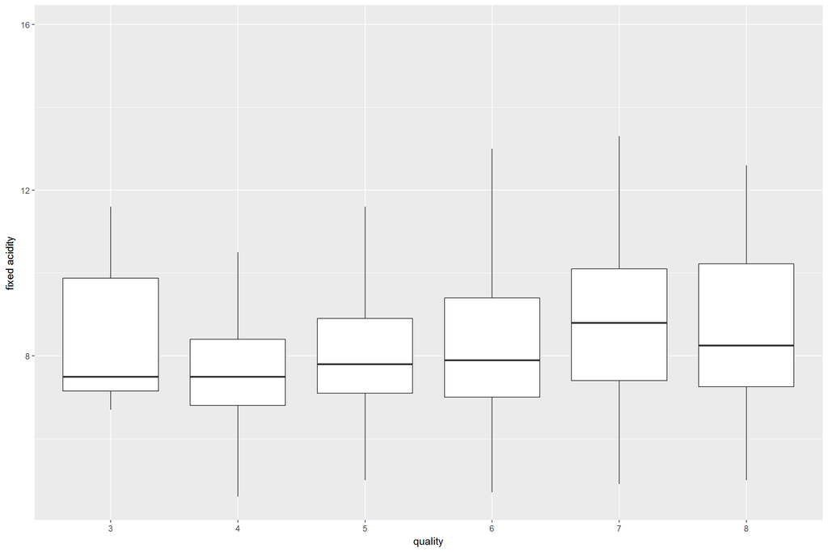

The median of the box plot has been increasing as the quality goes high, It there has been an sudden decrease observed at the end.

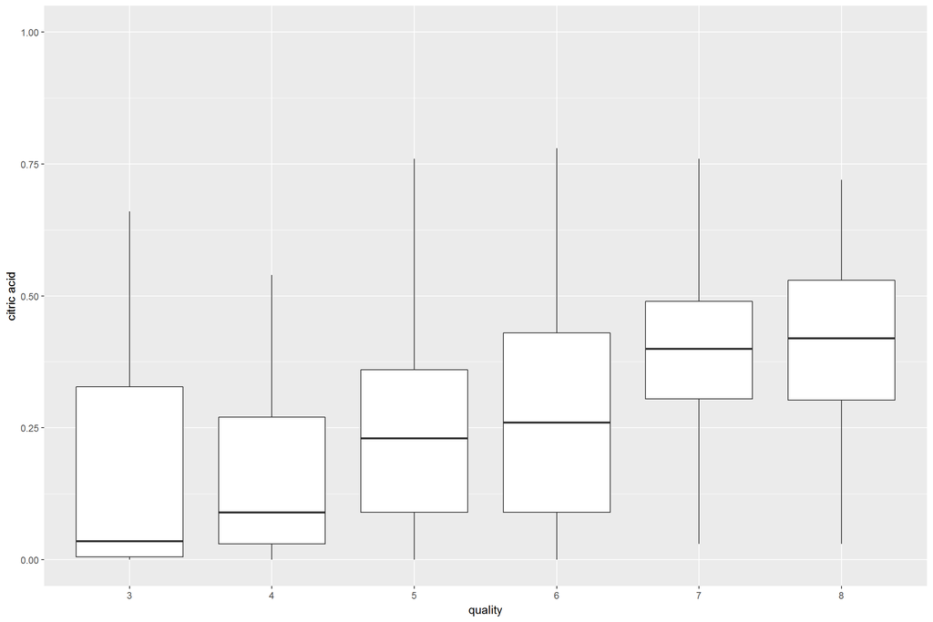

As the quality of wine increases the median of the citric acid in wines increases. Good wines are found to have citric.acid around 0.40

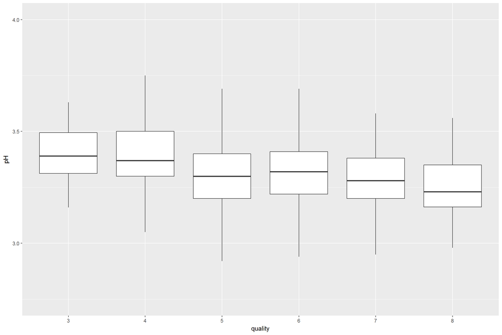

pH decreases with increase in the quality of the wine. Idea pH is found to be around 3.25

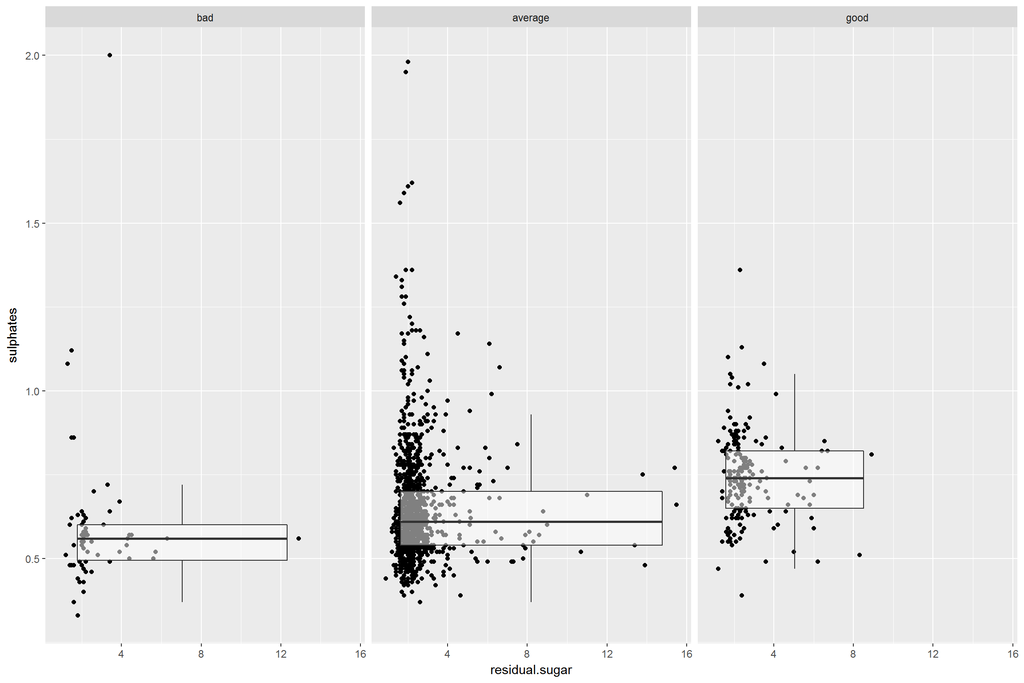

From the above plot it can be observed that a good quality wine has Sulphates(0.7-0.8).

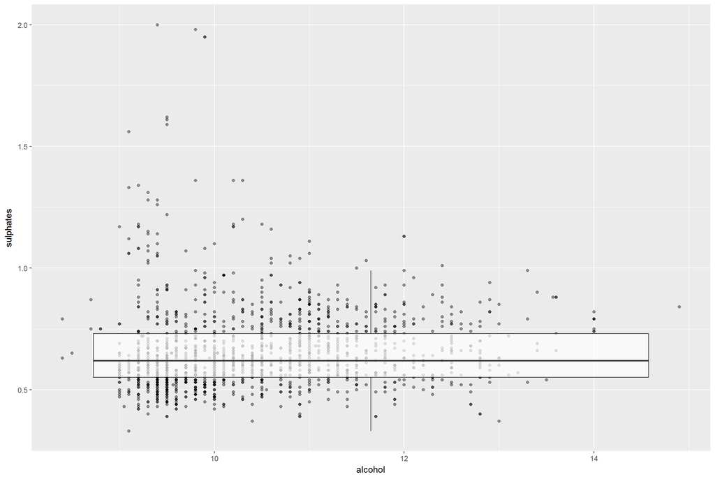

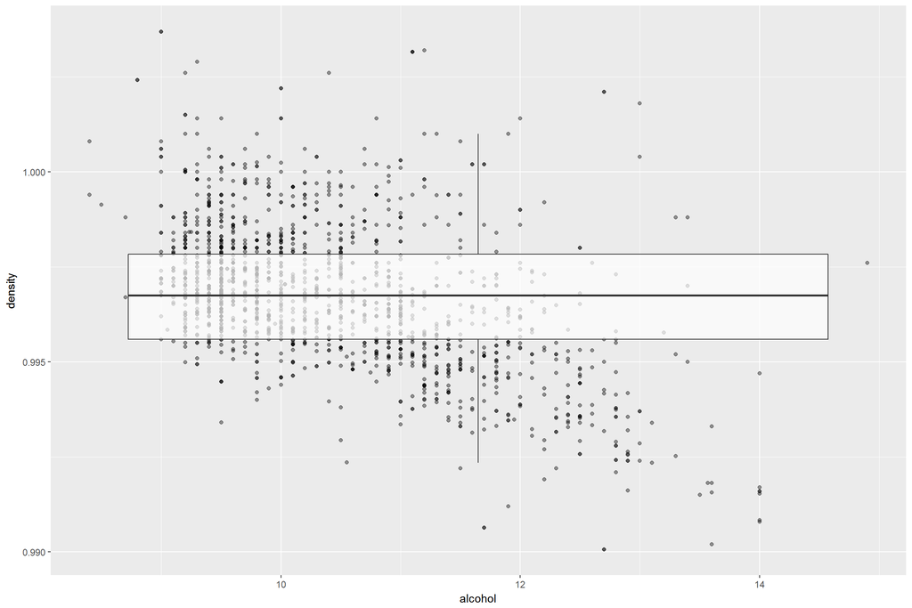

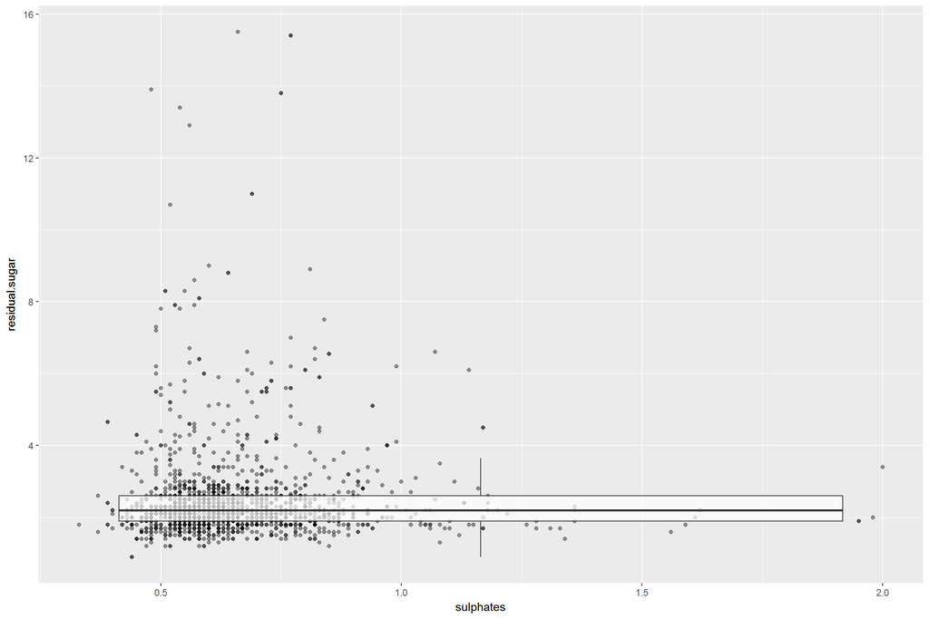

# Bivariate Analysis

from the above Co-Relation plot, Each charecteristics is compared agianst every other charecteristics and its co-relation factor is found. Its obsevrved that the Co-relation is highest between The co-relations is found to be highest between: 1. total.sulfur.dioxide and free.sulfur.dioxide -(0.7) 2. fixed.acidity and citric.acid -(0.7) 3. fixed.acidity and density - (0.7) 4. fixed.acidity and pH - (-0.7) 5. Volatile.acidity and citric.acid - (-0.6) Moderate between: 6. Quality and Alcohol -(0.5) 7. citric.acid and pH - (-0.5) 8. density and Alcohol - (-0.5) 9. Chlorides and Sulphates - (0.4) 10. residual.sugar and density- (0.4) 11. citric.acid and density -(0.4) 12. volatile.acidity and Quality - (-0.4) and a low co-relation between: 13. quality and Sulphates -(0.3) 14. citric.acid and sulphates -(0.3) 15. fixed.acidity and volatile.acidity - (-0.3) 16. volatile.acidity and sulphates - (-0.3) 17. chlorides and pH - (-0.3) 18. density and pH - (-0.3) Below are some of the observations from the Bivariate Plots: 1. It can be observed that a good quality wine has Sulphates ranging between 0.7 & 0.8. 2. pH decreases with increase in the quality of the wine. Ideal pH is found to be around 3.25. 3. The median of the box plot has been decreasing as the quality goes higher and is found to be stabilized at end as it reaches higher quality. Good quality wines have lower volatile.acidity around 0.4. 4. The median of the box plot has been increasing as the quality goes high, It there has been an sudden decrease observed at the end.

### Talk about some of the relationships you observed in this part of the investigation. How did the feature(s) of interest vary with other features in the dataset?

It has been observed that Quality is directly co-related to Alcohol, Sulphates and negetively co-related with Volatile.Acidity. these three factors were dependent on various other factors such as Chlorides, Citric.acid, density, pH, fixed acidity and Residual.sugars Keeping in mind the dependency’s of Individual Charecters on each other and their inflences it is Intresting to study the Independent Charecteristists and their dependency on wine Quality. Its is interesting to observe the Influence of Quality on 1. Alcohol and Density 2. sulphates and Chlorides. 3. Volatile.Acidity and Citric.acid It was observed that pH decreases with increase in the quality of the wine.

### What was the strongest relationship you found?

The co-relations is found to be highest between: 1. total.sulfur.dioxide and free.sulfur.dioxide -(0.7) 2. fixed.acidity and citric.acid -(0.7) 3. fixed.acidity and density - (0.7) 4. fixed.acidity and pH - (-0.7) 5. Volatile.acidity and citric.acid - (-0.6) 6. Quality and Alcohol - (0.5) as it can be understood that certain acidity impacts other forms of acidity, which explains the Strong Co-Relations Co-efficients above and these co-relations has very less impacts in Determining the quality of the wine Directly. Its is found that Quality is Mainly effected by Alcohol, Sulphates and Vol. Acidity. The strongest relation found was between Alcohol and Quality

# Multivariate Plots Section

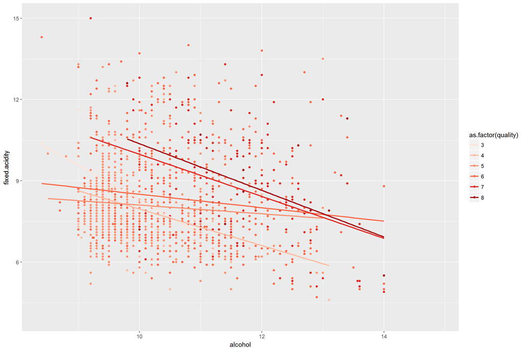

As it hs already been mentioned above, As per the areas of intrests are concerned, We will plot a Multivariate plots between: 1. Alcohol, Density and Residual Sugar. As quality is Co-related to Alcohol, Alcohol to Density and Density to Resudual sugar 2. Sulphates, chlorides and Citric Acid Similarly and also 3. Volatile Acidity, Citric Acid and Fixed acidity. We clustered these three varible into a group and Let us plot a box plot to understand the Behaviour of these varibles on Quality. Let us do these plot agianst a Raing varible we created for a Better Understand of the Dependencies.

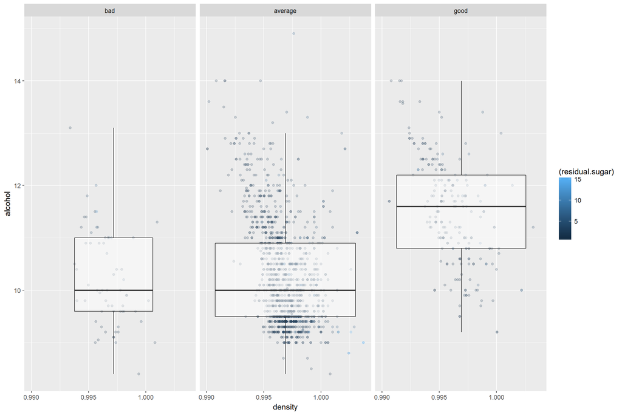

From the above plot it is clearly legible that Alcohol Content of a good quality wine ranges between (10.9 and 12.2) and and Density between (0.993 to 1.002)Approximately. The residual.sugar in the color brewer help in visually undertanding the conclusions drawn using other plots and the exact limit value of Residual Sugar need not be determined as it has no significance on quality that is Zero Co-Relation Coefficient.

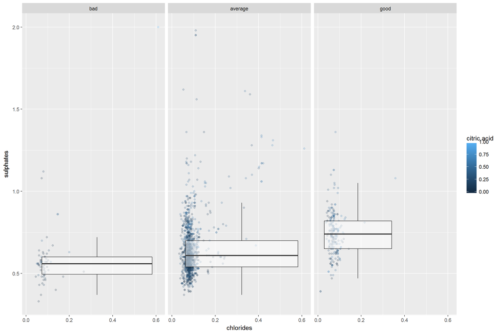

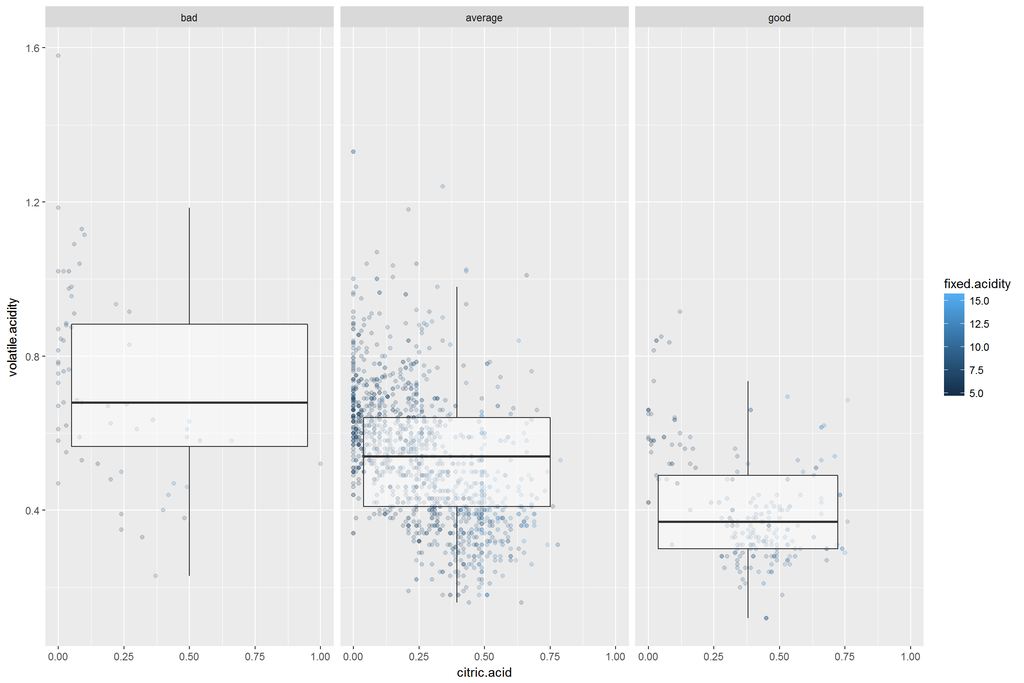

# Multivariate Analysis

### Were there any interesting or surprising interactions between features?

Yes, it is intresting how each section of the analysis revealed better understanding of the Wine Quality. From the Corr plot the various co-relations between charecterists have been studied and Observed. It is suprising to see the hidden revelations from the dataset as we explore the data.

# Final Plots and Summary

From the above analysis, the dependency of Individual charecteristics of a wine were studied. As per the areas of intrests are concerned, We will plot a Multivariate plots between: 1. Alcohol, Density and Residual Sugar. As quality is Co-related to Alcohol, Alcohol to Density and Density to Resudual sugar 2. Sulphates, chlorides and Citric Acid Similarly and also 3. Volatile Acidity, Citric Acid and Fixed acidity. We clustered these three varible into a group and Let us plot a box plot to understand the Behaviour of these varibles on Quality. Let us do these plot agianst a Raing varible we created for a Better Understand of the Dependencies.

### Plot One

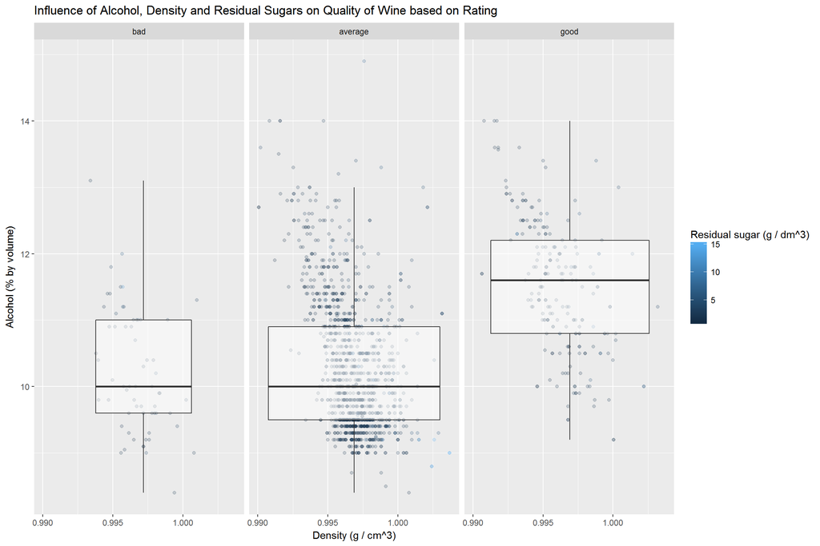